None

# Table of Contents

return home

# Vehicle Dynamics: Kinematics of a Turning Bicycle/Motorcycle

In this notebook, We will learn about how a two wheeled vehicle navigates a turn, or produces a curved path.

## Prerequisite Knowledge

To understand the material in this notebook, you should understand:

- Basic trigonometry, especially definitions of [sine, cosine, and tangent (https://en.wikipedia.org/wiki/Sine_and_cosine) in the context of right triangles
- [Angular Velocity](https://en.wikipedia.org/wiki/Angular_velocity), specifically "orbital angular velocity"
- How to manipulate quantities such as force, torque, and velocity represented as [vectors](https://en.wikipedia.org/wiki/Euclidean_vector) in Cartesian space. This includes how to compute their dot and cross products in three dimensions.
- [instantaneous center of rotation](https://en.wikipedia.org/wiki/Instant_centre_of_rotation)
- [ISO Vehicle Coordinate System](https://en.wikipedia.org/wiki/Axes_conventions#Frames_mounted_on_vehicles)

You can refer to the links above before reading the notebook, or you can wait until you're unsure about something you see in the text, and then click the link to fill in holes in your understanding.

## Problem Setup

Consider a two-wheeled vehicle navigating a turn at (relatively) low speeds, such that both of its wheels are moving (rolling) forwards relative to their respective headings, and not sliding laterally. The front wheel is steering about the gravitational ($\hat{k}$) direction, with an ISO standard, right-handed coordinate system fixed to the vehicle's rear wheel such that the $\hat{\imath}$ direction points forwards and the $\hat{\jmath}$ direction points left. This setup is shown below.

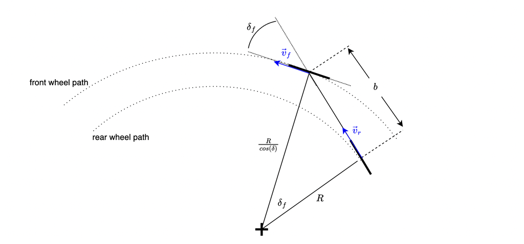

## The Vehicle's Instantaneous Center of Rotation (Turn Center)

When two velocity vectors on a rigid body are misaligned, it means the rigid body *rotates* as well as translates. If a rigid body rotates, it means that there is a point *somewhere* about which it *only* rotates. This point is called the *[instantaneous center of rotation](https://en.wikipedia.org/wiki/Instant_centre_of_rotation)* (ICR). For a vehicle, it's easy to conceptualize this point as "the center of the turn" the vehicle is navigating.

To find the ICR for a rigid body, we realize that if we consider the velocity of any point $p$ on the body with respect to a non-moving (ground) reference, we can write:

$$\vec{v}_p = \vec{\omega}\times\vec{r}_{p/IC},$$

where $\vec{r}_{p/IC}$ is the position of the point $p$ with respect to the instantaneous center, and $\vec{\omega}$ is the angular velocity of the rigid body. In top view, neglecting the vehicle's roll and pitch motion, this is the vehicle's *yaw rate* $\vec{\omega} = \dot{\psi}\hat{k}$. Then finding the ICR is as simple as substituting $\vec{v}_r = U\hat{\imath}$ and $\vec{\omega} = \dot{\psi}\hat{k}$ into the equation above.

That is an algebraically feasible way to solve for the ICR vector. However, the fact that *any* point on the vehicle will have velocity $\vec{v}_p$ as described above as a pure cross product of angular velocity and a position vector means that every point $p$ on on the vehicle will have a velocity that is *perpendicular* to the vector $\vec{r}_{p/IC}$. This means that a quick way to find the ICR is to draw lines perpendicular to both $\vec{v}_f$ and $\vec{v}_r$, and note where they meet. This point is the ICR!

## Relating $\delta_f$ to turn radius

If we define the vector $\vec{R}$ as the vector from the ICR to the rear wheel, describing the radius of the curved path traced by the rear wheel when the vehicle steers with $\delta_f$, then we can use right triangles to determine how that vector's length, $R$, and the steer angle $\delta_f$ are related.

Looking at the right triangle formed by the rear wheel contact, the front wheel contact, and the turn center in the figure above, we could write:

$$\tan \delta_f = \frac{b}{R}$$

If we assume that $\delta$ is a small angle, as we usually can, given that vehicle steering angles are almost less than $20^\circ$, we can approximate $\tan\delta_f = \frac{\sin \delta_f}{\cos \delta_f} \approx \frac{\delta_f}{1} = \delta_f$. Doing so allows us to solve for the turn radius $R$:

$$R = \frac{b}{\delta_f}$$

## Relating turn radius to yaw rate

The simplest way to do this is using the [arc length formula](https://www.cuemath.com/geometry/arc-length/). We know that the length $s$ along an arc can be written:

$$s = R\theta$$

where $\theta$ is the angle of an arc in radians, and $R$ is the arc's radius. For us, we could write the arc length formula for the vehicle's change in yaw angle $\Delta \psi$ corresponding with some forward motion of the vehicle:

$$\Delta S = R \Delta \psi$$

Then, looking at this change over a change in time $\Delta t$ and shrinking the change in time to zero, we see that we are taking the derivative of the arc length formula:

$$\dot{S} = R \dot{\psi}$$

Now, we remember that our velocity along the curve is simply the vehicle's forward velocity $U$, and we can write:

$$ U = R\dot{\psi}$$

## Relating steer angle to yaw rate

With the relationship between steering and turn radius, along with the relationship between turn radius and yaw rate, we can compute the yaw rate that results from a particular steering angle by rearranging the equations.

$$\dot{\psi} = \frac{U \delta_f}{b}$$

If we're studying a motorcycle or bicycle, we know that the "effective" steering angle on the ground plane for the bike is the $\hat{k}$-component of the true steering angle. If we use the following motorcycle coordinate system:

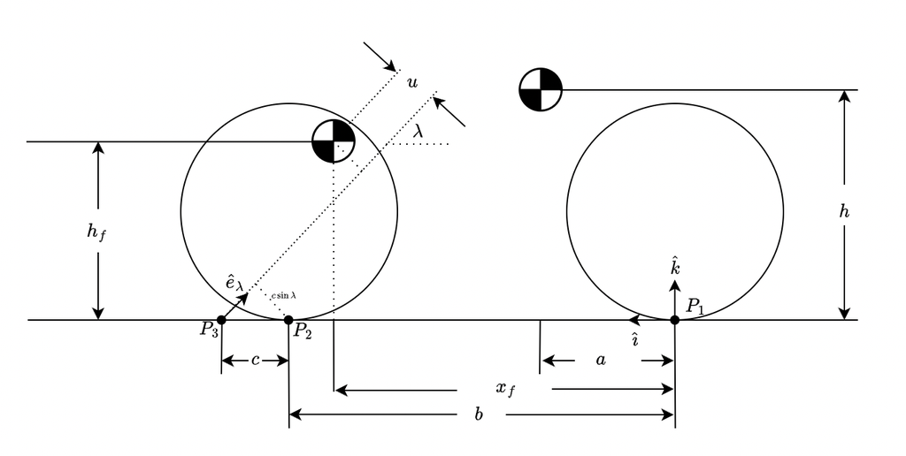

we can see that the vehicle is steered about the $\hat{e}_\lambda$ axis, so we could write:

$$\vec{\delta} = \delta \hat{e}\lambda = \delta\left(-\cos \lambda \hat{\imath} + \sin \lambda \hat{k}\right)$$

The $\hat{k}$-component of this vector is our "effective" steering angle $\delta_f$:

$$\delta_f = \vec{\delta}\cdot\hat{k} = \delta \sin \lambda$$

Substituting this in to our equation for yaw rate, we find that:

$$\dot{\psi} = \frac{U\sin \lambda}{b} \delta$$

## Contributions to yaw rate from steer rate

In addition to the yaw rate that is produced because of a steered wheel and nonzero forward velocity, a motorcycle or bicycle will also have yaw rate due to its [trail](https://en.wikipedia.org/wiki/Bicycle_and_motorcycle_geometry#Trail), or the distance of the tire contact patch behind the intersection of the steering axis with the ground. If the tires do not slip side to side when the bike is steered, the "lever arm" created by the trail will displace the rear frame of the bike as shown in the figure below. We can think about the distance from the rear contact path to the intersection of the steer axis with the ground plane as relatively constant for small steer angles, creating a "link" in a slider-crank style linkage that moves when we steer the bike.

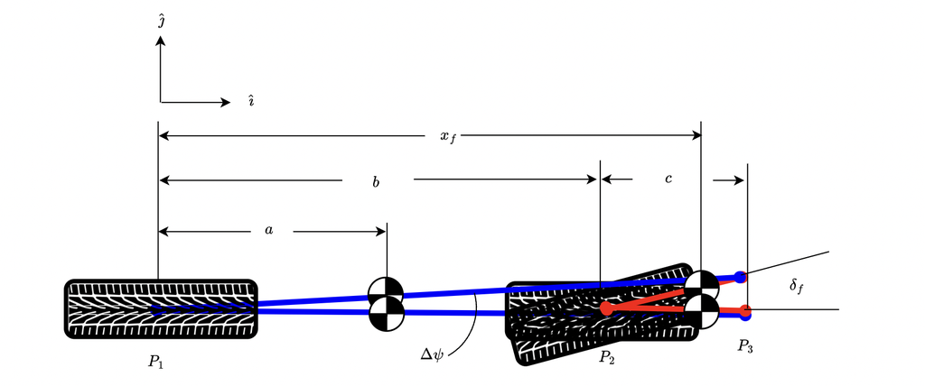

We already know that some yaw rate will result from any nonzero ground steer angle $\delta_f$, but there will also be a small change in the yaw angle of the "link" P1P3, which means the bike itself will experience a small change in yaw for any small steering motion. This means that as we think about small changes $\Delta \delta_f$ over a finite but shrinking time $\Delta t$ will converge to a steer rate $\dot{\delta}_f$, and result in a yaw rate $\dot{\psi}$.

Using trigonometry, we can write that: $$\Delta \psi = \frac{c\sin\delta_f}{b}$$

And for small $\delta_f = \delta\sin\lambda$ we can write an approximate yaw rate as:

$$\dot{\psi} = \frac{c\sin\lambda}{b}\dot{\delta}$$

## Total yaw rate resulting from steering motion of a motorcycle or bicycle

Summing the above two contributions to yaw rate, one from Ackermann geometry (turn radius) and the other from a combination of ground trail and steer rate, the approximate total yaw rate for a bicycle or motorcycle under small deviations from straight running and the no-tire-slip assumption can be written:

$$\dot{\psi} = \frac{U\sin \lambda}{b} \delta+\frac{c\sin\lambda}{b}\dot{\delta}$$